# Worked Examples for EES 3310/5310 Lab #2

Lab: Tue. Jan. 17

# Instructions

This file has worked examples: The first example show how to download measurements of carbon dioxide from the laboratory on Mauna Loa, Hawaii, that was started by C. David Keeling in 1958, analyze the data, and make plots and tables to show the results of your analysis.

After studying the worked example, you will do further analysis and plotting using both the CO<sub>2</sub> data from Mauna Loa and also global temperature measurements that you will download from NASA’s Goddard Institute for Space Studies.

The second example shows how to use `pivot_longer` and `pivot_wider` functions to manipulate a `data.frame` or `tibble`, and how to use grouping and summarizing functions.

# Worked Example

## Downloading CO<sub>2</sub> Data from Mauna Loa Observatory

We can download the data from https://scrippsco2.ucsd.edu/assets/data/atmospheric/stations/in_situ_co2/monthly/monthly_in_situ_co2_mlo.csv. We can download the file and save it to the local computer using the R function `download.file`

Here, I use the `file.exists` function so I only download the file if it doesn’t already exist. That avoids having to download it again if you already have it.

```r
if (!file.exists('_data/mlo_data.csv')) {
  download.file(mlo_url, '_data/mlo_data.csv')
}
```

Try opening the data file in Excel or a text editor.

The first 54 lines of the data file are comments describing the data. These comments describe the contents of each column of data and explain that this data file uses the special value `-99.99` to indicate a missing value. The Mauna Loa Observatory started recording data in March 1958, so the monthly averages for January and February are missing. Other months are missing for some months in the record when the instruments that monitor CO<sub>2</sub> concentrations were not working properly.

The `read_csv` function from the `tidyverse` package can read the data into R and convert it into a data structure that we call a `tibble` or a `data.frame` (it’s kind table of data, similar to the way data is organized in an Excel spreadsheet).

When R reads in `.csv` files, it expects column names to be on a single row, and lines 55–57 of the data file are column headings that are split across multiple rows, so R will get confused if we tell it to use those rows as column names.

To avoid problems, we will tell `read_csv` to read this data file, but skip the first 57 lines. We will also tell it not to look for column names in the data file, so we will supply the column names, and we will tell it that whenever it sees `-99.99`, it should interpret that as indicating a missing value, rather than a measurement.

Finally, R can guess what kinds of data each column contains, but for this file, things work a bit more smoothly if we provide this information explicitly.

`read_csv` lets us specify the data type for each column by providing a string with one letter for each column. The letters are `i` for integer numbers, `d` for real numbers (i.e., numbers with a decimal point and fractional parts), `n` for an unspecified number, `c` for character (text) data, `l` for logical (`TRUE` or `FALSE`), `D` for calendar dates, `t` for time of day, and `T` for combined date and time.

```r
mlo_data = read_csv('_data/mlo_data.csv',
                    skip = 57,  # skip the first 57 rows
                    col_names = c('year', 'month', 'date_excel', 'date',
                                  'co2_raw', 'co2_raw_seas',
                                  'co2_fit', 'co2_fit_seas',
                                  'co2_filled', 'co2_filled_seas'),
                    col_types = 'iiiddddddd',
                    # ^^^ the first three columns are integers and the  next
                    # 7 are real numbers
                    na = '-99.99'
                    # ^^^ interpret -99.99 as a missing value
)
```

Let’s look at the first few rows of the data:

Here is how it looks in R:

```r
head(mlo_data)
```

```
## # A tibble: 6 × 10
##    year month date_excel  date co2_raw co2_raw…¹ co2_fit co2_f…² co2_f…³ co2_f…⁴
##   <int> <int>      <int> <dbl>   <dbl>     <dbl>   <dbl>   <dbl>   <dbl>   <dbl>
## 1  1958     1      21200 1958.     NA        NA      NA      NA      NA      NA
## 2  1958     2      21231 1958.     NA        NA      NA      NA      NA      NA
## 3  1958     3      21259 1958.    316.      314.    316.    315.    316.    314.
## 4  1958     4      21290 1958.    317.      315.    317.    315.    317.    315.
## 5  1958     5      21320 1958.    318.      315.    318.    315.    318.    315.
## 6  1958     6      21351 1958.     NA        NA     317.    315.    317.    315.
## # … with abbreviated variable names ¹co2_raw_seas, ²co2_fit_seas, ³co2_filled,
## #   ⁴co2_filled_seas
```

There are six different columns for the CO<sub>2</sub> measurements:

- `co2_raw` is the raw measurement from the instrument. The measurements began in March 1958, so there are `NA` values for January and February. In addition, there are missing values for some months when the instrument was not working well.
- `co2_fit` is a smoothed version of the data, which we will not use in this lab.
- `co2_filled` is the same as `co2_raw`, except that where there are missing values in the middle of the data, they have been filled in with interpolated estimates based on measurements before and after the gap.

For each of these three data series, there is also a *seasonally adjusted* version, which attempts to remove the effects of seasonal variation in order to make it easier to observe the trends.

For this lab, we will focus on the `co2_filled` data series. To keep things simple, we can use the `select` function from `tidyverse` to keep only certain columns in the tibble and get rid of the ones we don’t want.

```r
mlo_simple = mlo_data %>% select(year, month, date, co2 = co2_filled)

head(mlo_simple)
```

```
## # A tibble: 6 × 4
##    year month  date   co2
##   <int> <int> <dbl> <dbl>
## 1  1958     1 1958.   NA
## 2  1958     2 1958.   NA
## 3  1958     3 1958.  316.
## 4  1958     4 1958.  317.
## 5  1958     5 1958.  318.
## 6  1958     6 1958.  317.
```

Note how we renamed the `co2_filled` column to just plain `co2` in the select function. There are some missing measurements from months where the laboratory instruments were not working properly. These are indicated by `NA`, meaning “not available.”

We can also use the `kable()` function from the `knitr` package to format the data nicely as a table in an RMarkdown document. Notice how I can use RMarkdown formatting in the column names and caption to make the “2” in CO<sub>2</sub> appear as a subscript.

```r
head(mlo_simple) %>%
  kable(col.names = c(year = "Year", month = "Month", date = "Date",
                      co2 = "CO~2~ (ppm)"),
        caption = "A table of monthly CO~2~ measurements from Mauna Loa.")
```

A table of monthly CO<sub>2</sub> measurements from Mauna Loa.

| Year | Month | Date | CO<sub>2</sub> (ppm) |
| --- | --- | --- | --- |
| 1958 | 1 | 1958.041 | NA |
| 1958 | 2 | 1958.126 | NA |
| 1958 | 3 | 1958.203 | 315.71 |
| 1958 | 4 | 1958.288 | 317.45 |
| 1958 | 5 | 1958.370 | 317.51 |
| 1958 | 6 | 1958.455 | 317.26 |

Now, let’s plot this data:

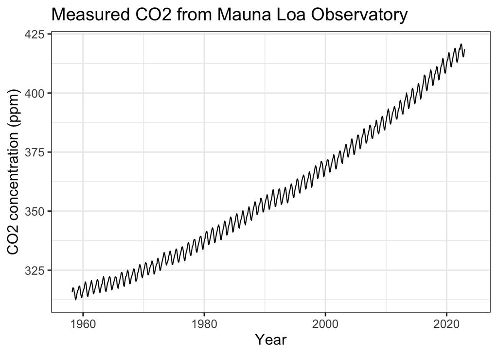

Monthly CO<sub>2</sub> measurements from Mauna Loa.

```r
ggplot(mlo_simple, aes(x = date, y = co2)) +
  # ^^^ The ggplot command specifies which data to plot and the aesthetics that
  # define which variables to  use for the x and y axes.
  geom_line() +
  # ^^^ The geom_line() command says to plot lines connnecting the data points
  labs(x = "Year", y = "CO2 concentration (ppm)",
       title = "Measured CO2 from Mauna Loa Observatory")
  # ^^^ The labs() command tells ggplot what names to use in labeling the axes
  # and the title for the plot.

  # Earlier in this .Rmd file, I called set_theme(theme_bw(base_size = 15))
  # to set the default plot style. If you call ggplot() without this,
  # you will get a different style, but you can either call theme_set
  # or you can add a theme specification (such as
  # "+ theme_bw(base_size = 15)")
  # to the end of the sequence of plotting commands in order to
  # apply a specific style to an individual plot.
```

I created a caption for the figure caption by adding the following specification to the header of the R code chunk in the RMarkdown document:

```r
fig.cap="Monthly CO~2~ measurements from Mauna Loa."
```

Notice the seasonal variation in CO<sub>2</sub>. Every year, there is a large cycle of CO<sub>2</sub>, but underneath is a gradual and steady increase from year to year. If we wanted to look at the trend without the seasonal variation, we could use the `co2_filled_seas` column of the original tibble, but instead, let’s look at how we might estimate this ourselves.

The seasonal cycle is 12 months long and it repeats every year. This means that if we average the values in our table over a whole year, this cycle should average out. We can do this by creating a new column `annual` where every row represents the average over a year centered at that row (technically, all the months from 5 months before through six months after that date).

To do this, we use the function `slide_vec` from the `slider` package, as shown below. The `slide_vec` function allows you to take a series of data (such as monthly CO<sub>2</sub> measurements) and at each point, apply a function to the data within a “window” that includes a certain number of points before and after the point in question.

Here, we apply the `mean` function to take the average, and we define the “window” to be the 12 points roughly centered on the point in question, so for each month in our data series, `slide_vec` takes the average of the 12 measurements roughly centered on that month (technically, the month, the five months before, and the six months after). You could also specify `.before = 0, .after = 11` to take the 12 months starting with the given month, or `.before = 11, .after = 0` to take the 12 months ending with the given month.

There will be months at the beginning of the series that don’t have five months of data before them and points at the end of the series that don’t have six months after them. By default `slide_vec` sets those points to `NA`, which is a special value R uses to indicate missing values (`NA` means “not available”).

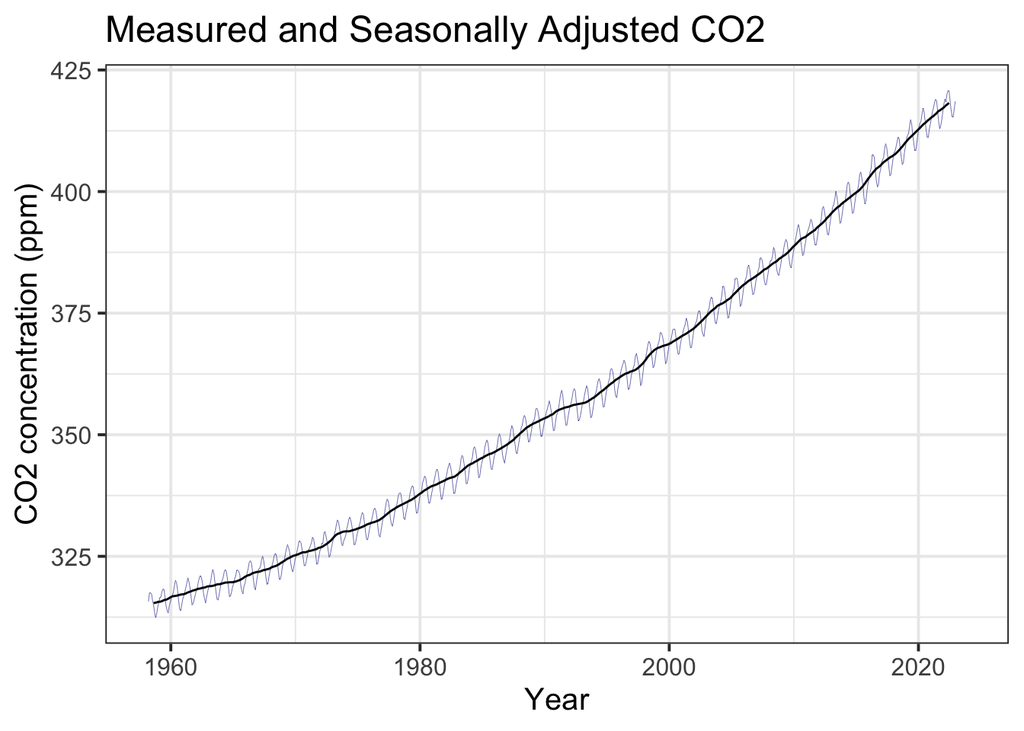

Raw and seasonally adjusted measurements of atmospheric CO<sub>2</sub>, from Mauna Loa.

```r
mlo_simple %>%
  mutate(annual = slide_vec(co2, mean, .before = 5, .after = 6)) %>%
  ggplot(aes(x = date)) +
  geom_line(aes(y = co2), color = "darkblue", size = 0.1) +
  geom_line(aes(y = annual), color = "black", size = 0.5) +
  labs(x = "Year", y = "CO2 concentration (ppm)",
       title = "Measured and Seasonally Adjusted CO2")
```

But wait: we might want a legend to tell the reader what each colored line represents. We can create new aesthetics for the graph mapping to do this:

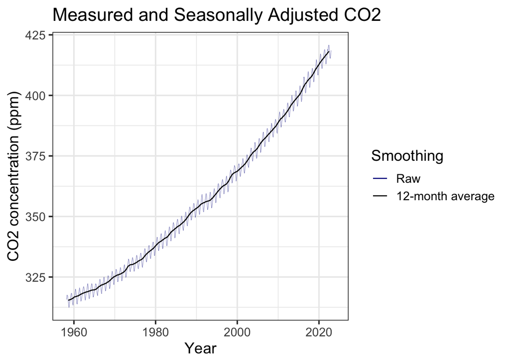

Raw and seasonally adjusted measurements of atmospheric CO<sub>2</sub>, from Mauna Loa, with a legend identifying the different lines.

```r
mlo_simple %>%
  mutate(annual = slide_vec(co2, mean, .before = 5, .after = 6)) %>%
  ggplot(aes(x = date)) +
  geom_line(aes(y = co2, color = "Raw"), size = 0.1) +
  geom_line(aes(y = annual, color = "12-month average"), size = 0.5) +
  scale_color_manual(values = c("Raw" = "darkblue",
                                "12-month average" = "black"),
                     name = "Smoothing") +
  labs(x = "Year", y = "CO2 concentration (ppm)",
       title = "Measured and Seasonally Adjusted CO2")
```

We can also anlyze this data to estimate the average trend in CO<sub>2</sub>. We use the `lm` function in R to fit a straight line to the data, and we use the `tidy` function from the `broom` package to print the results of the fit nicely.

R has many powerful functions to analyze data, but here we will just use a very simple one. We specify the linear relationship to fit using R’s formula language. If we want to tell R that we think `co2` is related to `date` by the linear relationship $co2 = a + b \times \text{date}$, then we write the formula `co2 ~ date`. The intercept is implicit, so we don’t have to spell it out.

```r
co2_fit = lm(co2 ~ date, data = mlo_simple)

library(broom)

tidy(co2_fit)
```

```
## # A tibble: 2 × 5
##   term        estimate std.error statistic p.value
##   <chr>          <dbl>     <dbl>     <dbl>   <dbl>
## 1 (Intercept) -2847.    18.1         -157.       0
## 2 date            1.61   0.00910      177.       0
```

This shows us that the trend is for CO<sub>2</sub> to rise by 1.61 ppm per year, with an uncertainty of plus or minus 0.009.

If we want to assign the value of the trend to a variable, we do it like this:

```r
co2_trend = coef(co2_fit)['date']

print(co2_trend)
```

```
##     date
## 1.609673
```

We can also plot a linear trend together with the data:

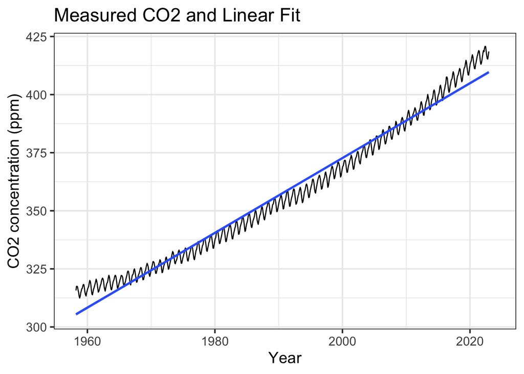

Trend in atmospheric CO<sub>2</sub>.

```r
mlo_simple %>%
  ggplot(aes(x = date, y = co2)) +
  geom_line() +
  geom_smooth(method = 'lm') +
  labs(x = "Year", y = "CO2 concentration (ppm)",
       title = "Measured CO2 and Linear Fit")
```

# Exercises

In the file `lab-02-report.Rmd`, complete the exercises, filling in the code and explanatory text and answering the questions in the exercises.

You can copy code from these worked examples and edit it to apply it to the exercises in the lab report file.

## Pivoting Data Frames

If you have data in a `tibble` or `data.frame`, you can re-organize it to make it easier to analyze. We use the functions `pivot_longer` and `pivot_wider` for this.

Here is an example of using `pivot_longer`, using a data set of quarterly approval ratings for U.S. presidents from 1945–2021:

```r
df = read_rds(file.path(data_dir, "presidential_approval.Rds"))

print("First 10 rows of df are")
```

```
## [1] "First 10 rows of df are"
```

```r
print(head(df, 10))
```

```
## # A tibble: 10 × 6
##    president             year    Q1     Q2     Q3    Q4
##    <chr>                <int> <dbl>  <dbl>  <dbl> <dbl>
##  1 Harry S. Truman       1945  NA    84     NA     67
##  2 Harry S. Truman       1946  23.3   0.5  -19    -15.5
##  3 Harry S. Truman       1947  29.3  32.3   29.5   21
##  4 Harry S. Truman       1948  21    -8.67  NA     NA
##  5 Harry S. Truman       1949  42.5  24.5   14     NA
##  6 Harry S. Truman       1950  -1    -3.5   -0.25  -8
##  7 Harry S. Truman       1951 -27   -34.3  -24.3  -32
##  8 Harry S. Truman       1952 -41   -29.5  -30    -23.8
##  9 Dwight D. Eisenhower  1953  62    63.5   53.8   40.5
## 10 Dwight D. Eisenhower  1954  48.8  40     46.2   38.3
```

For each year, the table has a column for the president, a column for the year, and four columns (Q1 … Q4) that hold the quarterly net-approval ratings for the president in that quarter. Now we want to organize these data into four columns: one column for the president, one column for the year, one column to indicate the quarter, and one column to indicate the net approval rating.

We do this with the `pivot_longer` function. the pivot_longer command organizes the data into tidy columns:

So the approval ratings from the second quarter of 1960 will be stored in a row where the column `president` contains “Dwight D. Eisenhower”, `year` contains 1960, `quarter` contains “Q2”, and `net_approval` contains the net approval rating.

I also use the `arrange()` command to sorts the rows of the resulting data frame to put the years in ascending order, from 1945 to 2021, and within each year, sort the quarters in alphabetical order from Q1 to Q4

```r
df_long = df %>%
  pivot_longer(cols = -c(president, year),
               names_to = "quarter", values_to = "net_approval") %>%
  arrange(year, quarter)

head(df_long) # print the first few rows of the tibble.
```

```
## # A tibble: 6 × 4
##   president        year quarter net_approval
##   <chr>           <int> <chr>          <dbl>
## 1 Harry S. Truman  1945 Q1              NA
## 2 Harry S. Truman  1945 Q2              84
## 3 Harry S. Truman  1945 Q3              NA
## 4 Harry S. Truman  1945 Q4              67
## 5 Harry S. Truman  1946 Q1              23.3
## 6 Harry S. Truman  1946 Q2               0.5
```

We can use the `pivot_wider` function to do the opposite and pivot our new data frame back to the original format:

```r
df_wide = df_long %>%
  pivot_wider(names_from = "quarter", values_from = "net_approval") %>%
  arrange(year)

head(df_wide) # print the first few rows of the tibble.
```

```
## # A tibble: 6 × 6
##   president        year    Q1    Q2     Q3    Q4
##   <chr>           <int> <dbl> <dbl>  <dbl> <dbl>
## 1 Harry S. Truman  1945  NA   84     NA     67
## 2 Harry S. Truman  1946  23.3  0.5  -19    -15.5
## 3 Harry S. Truman  1947  29.3 32.3   29.5   21
## 4 Harry S. Truman  1948  21   -8.67  NA     NA
## 5 Harry S. Truman  1949  42.5 24.5   14     NA
## 6 Harry S. Truman  1950  -1   -3.5   -0.25  -8
```

### Grouping and Summarizing

Now suppose we want to find the average approval for each year? We can use the functions `group_by` and `summarize` with `df_long`. `group_by(df, year)` or `df %>% group_by(year)` group the rows of the data frame into groups that have the same year (so there is a group for each year, each of which contains the rows for the four quarters of that year), and then `summarize(net_approval = mean(net_approval))` replaces those four rows in each group with the average over all four quarters.

After you call `summarize` you usually want to ungroup your data, because it’s generally easier to work with ungrouped data unless you have a reason to group it. You do this with `ungroup(df)` or `df %>% ungroup()`.

```r
df_annual = df_long %>% group_by(year) %>%
  summarize(net_approval = mean(net_approval, na.rm = TRUE)) %>%
  ungroup()

head(df_annual)
```

```
## # A tibble: 6 × 2
##    year net_approval
##   <int>        <dbl>
## 1  1945        75.5
## 2  1946        -2.67
## 3  1947        28.0
## 4  1948         6.17
## 5  1949        27
## 6  1950        -3.19
```

The `na.rm = TRUE` argument to `mean` in the code above tells R to ignore rows where `net_approval` has a missing (`NA`, or “not available”) value. Normally, if there is a missing value in a function like `mean` or `max` or `min`, or `sum`, the result is `NA` because you’re trying to take the average (or maximum, minumum, sum, etc.) of a bunch of numbers where some are missing, so you don’t know what the average is. Functions like these often have an option to call them with `na.rm = TRUE`, that calculates the mean, minimum, maximum, sum, or whatever for the values that are known, and ignore any missing values.

You can also group by multiple variables at once:

```r
df_annual = df_long %>% group_by(year, president) %>%
  summarize(net_approval = mean(net_approval, na.rm = TRUE)) %>%
  ungroup()

head(df_annual)
```

```
## # A tibble: 6 × 3
##    year president       net_approval
##   <int> <chr>                  <dbl>
## 1  1945 Harry S. Truman        75.5
## 2  1946 Harry S. Truman        -2.67
## 3  1947 Harry S. Truman        28.0
## 4  1948 Harry S. Truman         6.17
## 5  1949 Harry S. Truman        27
## 6  1950 Harry S. Truman        -3.19
```